# Week 10: Sensors for Autonomy

EE0849 Introduction to Robotics

Basri Erdogan

## This Week’s Goals

1. Explain the **sense-plan-act** loop and classify sensors as proprioceptive vs exteroceptive
2. Describe how **LiDAR** works and convert a scan from polar to Cartesian coordinates
3. Use basic **OpenCV** operations (thresholding, contours) to extract information from camera images
4. Build a **binary occupancy grid** from a LiDAR scan using ray casting
5. Apply the **log-odds update** rule to fuse multiple scans into a single occupancy map

# Part 1: From Motion to Perception

## The Blind Robot Problem

Last week we derived kinematic models:

$$\dot{q} = G(q)\,u$$

We can command wheel speeds, predict how the pose changes…

**But:** the robot has no idea what’s around it.

- Where are the walls?
- Is there an obstacle ahead?
- Where is the goal?

**Motion without perception is useless.**

[figure not shown]

## The Sense-Plan-Act Loop

[figure not shown]

The simplest model of autonomous behavior: **sense → plan → act → repeat**.

- **Sense** (W10): perceive the environment
- **Plan** (W11–W12): decide what to do
- **Act** (W09): execute motion

This week we focus on **SENSE**.

## Sensor Taxonomy

|  | **Proprioceptive** | **Exteroceptive** |
| --- | --- | --- |
| **Measures** | Robot’s own state | External environment |
| **Examples** | Wheel encoders, IMU, battery voltage | LiDAR, camera, ultrasonic, bumper |
| **Needs** | Nothing external | Objects/surfaces to interact with |

**Tip**

**Connection to W09:** Wheel encoders are proprioceptive sensors. In W09’s differential-drive model, we used encoder counts to compute $v$ and $\omega$ – that’s **odometry**, a proprioceptive measurement. Today we add exteroceptive sensors to see the world.

# Part 2: Range Sensing – LiDAR

## How LiDAR Works

**Light Detection And Ranging**

1. Emit a short laser pulse
2. Pulse reflects off a surface
3. Measure the round-trip time $\Delta t$

$$d = \frac{c \cdot \Delta t}{2}$$

where $c = 3 \times 10^8$ m/s (speed of light).

**One pulse = one distance measurement.**

[figure not shown]

## From a Single Pulse to a 2D Scan

The sensor **sweeps** the laser beam through 360 degrees.

At each angle $\alpha_i$, the sensor records a range $r_i$.

One full rotation = one **scan** = array of $(r_i, \alpha_i)$ pairs.

Typical: **360 measurements per scan** (1 degree resolution).

[interactive chart not shown]

## What the Data Looks Like

A single scan is an array:

$$\{(r_0, \alpha_0),\; (r_1, \alpha_1),\; \ldots,\; (r_{N-1}, \alpha_{N-1})\}$$

where:

- $r_i$ = measured range (meters)
- $\alpha_i = i \cdot \Delta\alpha$ (radians)
- $N$ = number of rays per scan
- $\Delta\alpha$ = angular resolution

In Python: `ranges[i]` gives $r_i$.

[figure not shown]

## Polar to Cartesian Conversion

Each $(r_i, \alpha_i)$ becomes an $(x_i, y_i)$ point:

$$x_i = r_i \cos(\alpha_i)$$
$$y_i = r_i \sin(\alpha_i)$$

The set of all points $\{(x_i, y_i)\}$ is called a **point cloud**.

In NumPy:

```python
x = ranges * np.cos(angles)
y = ranges * np.sin(angles)
```

[interactive chart not shown]

## Point Clouds in the World Frame

The LiDAR gives points in the **sensor frame** $\{S\}$. To build a map, we need points in the **world frame** $\{W\}$.

It’s a 2D rotation and translation:

$$\begin{bmatrix} x^W_i \\ y^W_i \end{bmatrix} = \underbrace{\begin{bmatrix} \cos\theta & -\sin\theta \\ \sin\theta & \cos\theta \end{bmatrix}}_{\text{rotate by } \theta} \begin{bmatrix} x^S_i \\ y^S_i \end{bmatrix} + \underbrace{\begin{bmatrix} x_R \\ y_R \end{bmatrix}}_{\text{translate to robot}}$$

Packed as a single matrix multiply (the 2D version of W02’s $T_{WS}$):

$$\begin{bmatrix} x^W_i \\ y^W_i \\ 1 \end{bmatrix}
= \underbrace{\begin{bmatrix} \cos\theta & -\sin\theta & x_R \\ \sin\theta & \cos\theta & y_R \\ 0 & 0 & 1 \end{bmatrix}}_{T_{WS}(x_R,\, y_R,\, \theta)}
\begin{bmatrix} x^S_i \\ y^S_i \\ 1 \end{bmatrix}$$

Same math as the $4 \times 4$ homogeneous transforms from W02, one dimension smaller.

## It All Connects

This transform is the bridge between everything we’ve built so far:

- **W01:** Rotation matrices
- **W02:** Homogeneous transforms
- **W09:** Robot pose $(x_R, y_R, \theta)$ from odometry
- **W10:** Sensor data $(x^S_i, y^S_i)$ from LiDAR

Without it, sensor data from different robot positions would not be consistent, and we couldn’t build a coherent map.

**Tip**

Same math as W01–W02, just in 2D instead of 3D.

## Practical LiDAR Specs

[figure not shown]

$100

RPLIDAR A1

2D, mechanical

Range 12 m

Rate 5.5 Hz

Res. 1.0°

[figure not shown]

$4,000

Hokuyo UTM-30LX

2D, mechanical

Range 30 m

Rate 40 Hz

Res. 0.25°

[figure not shown]

$1,500

SICK TiM571

2D, solid-state

Range 25 m

Rate 15 Hz

Res. 0.33°

[figure not shown]

$4,000

Velodyne VLP-16

3D, 16 channels

Range 100 m

Rate 20 Hz

Res. 0.2°

**Note**

**Lab 9** simulates a sensor similar to the RPLIDAR A1: 2D, ~360 rays, ~10 m range.

## LiDAR Limitations

LiDAR is not perfect:

- **Glass**: beam passes through
- **Dark / matte surfaces**: weak return
- **Mirrors, polished metal**: specular bounce
- **Rain, fog, dust**: scatters the beam
- **Min range** (~15 cm): too close to measure
- **2D scan is one plane**: misses overhangs

[figure not shown]

# Part 3: Vision Sensing – Camera Basics

## The Camera as a Sensor

An **image** is an $H \times W$ grid of pixels; each pixel stores $(B, G, R) \in [0, 255]$.

**Cameras give** (LiDAR doesn’t):

- Color, texture, appearance
- Object recognition (shape, text, faces)
- High pixel resolution

**Cameras lack:**

- Direct depth
- Lighting independence

[figure not shown]

## Image Coordinates vs World Coordinates

**Image** $(u, v)$: origin top-left, $u$ = column, $v$ = row.

**World** $(x, y, z)$: 3D position.

A camera projects 3D onto 2D:
$$(x, y, z) \;\to\; (u, v)$$

**Depth is lost** — one pixel could be a small nearby object or a large distant one.

[figure not shown]

## Basic OpenCV: From Image to Information

```python
import cv2
import numpy as np

# 1. Load image
img = cv2.imread('scene.jpg')

# 2. Convert BGR -> HSV
hsv = cv2.cvtColor(img, cv2.COLOR_BGR2HSV)

# 3. Threshold: keep only red pixels
#    values are [H, S, V]
lower_red = np.array([ 0, 120,  70])  # H,S,V min
upper_red = np.array([10, 255, 255])  # H,S,V max
mask = cv2.inRange(hsv, lower_red, upper_red)

# 4. Find contours (outlines)
contours, _ = cv2.findContours(mask,
    cv2.RETR_EXTERNAL, cv2.CHAIN_APPROX_SIMPLE)
```

**Load** $\to$ **Color convert** $\to$ **Threshold** $\to$ **Contours**

**Why HSV, not BGR?**

BGR mixes color and brightness — a red ball looks different in shade vs. sunlight. HSV splits them:

- **H** — Hue (color angle) `[0, 179]`
- **S** — Saturation (vividness) `[0, 255]`
- **V** — Value (brightness) `[0, 255]`

Thresholding on **H** picks “red” across lighting changes.

**Careful — hue is circular.** In OpenCV red sits at **both** ends:

```
H=0   red         H=90   cyan
H=30  yellow      H=120  blue
H=60  green       H=179  red (wraps)
```

So `H ∈ [0, 10]` misses the reds around `H ∈ [170, 179]`. Build **two** masks and OR them.

## Color Thresholding: Finding a Red Ball

[figure not shown]

The binary mask isolates regions matching the target color. The contour gives us the **position** and **size** of the detected object.

## From Contours to Robot Decisions

```python
if contours:
    # Largest contour = most likely our target
    c = max(contours, key=cv2.contourArea)

    # Bounding box: x, y, width, height
    x, y, w, h = cv2.boundingRect(c)

    # Center of the object in image
    cx = x + w // 2
    cy = y + h // 2

    # Robot decision: is the object left, center, or right?
    img_center = img.shape[1] // 2
    if cx < img_center - 50:
        action = "turn left"
    elif cx > img_center + 50:
        action = "turn right"
    else:
        action = "go straight"
```

## Depth Cameras: Getting the Best of Both

Modern robots often use **RGB-D cameras** that give color image + per-pixel depth:

| Sensor | Principle | Typical Range |
| --- | --- | --- |
| **Microsoft Kinect v2** | Time-of-flight (ToF) IR | 0.5–4.5 m |
| **Intel RealSense D435** | Stereo + IR projector | 0.3–3 m |
| **iPhone Pro / iPad Pro** | Solid-state ToF LiDAR | 0.1–5 m |

**Note**

**Not in this course, but worth knowing**: an RGB-D camera fixes the “camera has no depth” problem. Each pixel becomes a 3D point, so you get a dense point cloud + color. Scales to **hundreds of thousands of points per frame**, compared to a 2D LiDAR’s ~360.

## Camera vs LiDAR: Trade-offs

|  | **LiDAR** | **Camera** |
| --- | --- | --- |
| **Direct depth?** | Yes (range per ray) | No (2D projection) |
| **Color / texture?** | No | Yes |
| **Works in dark?** | Yes (active sensor) | No (needs light) |
| **Cost** | $100–$4,000+ | $10–$100 |
| **Data rate** | ~100K points/sec | ~30 frames/sec |
| **Best for** | Mapping, obstacle avoidance | Object recognition, tracking |

**Note**

**For this course:** we use LiDAR data for mapping (W10) and path planning (W11–W12). Camera-based perception is a full course on its own.

# Part 4: From Sensor Data to Maps

## The Representation Problem

The environment is **continuous**; algorithms need a **discrete** representation.

| Representation | Idea | Pros | Cons |
| --- | --- | --- | --- |
| **Feature map** | List of landmarks | Compact, semantic | Hard to query “is this free?” |
| **Topological map** | Graph of places | Compact, high-level | No metric info |
| **Occupancy grid** | Grid of free/occupied cells | Full spatial info, easy planning | Memory-heavy |

**We use the occupancy grid** — direct input to grid-based planning (W11: Dijkstra, A*).

## The Occupancy Grid

A 2D array where each cell stores:

- **Free** (0): the robot can drive here
- **Occupied** (1): there’s an obstacle here
- **Unknown** (-1): not yet observed

**Parameters:**

- **Origin**: $(x_{\min}, y_{\min})$
- **Resolution**: cell size in meters (e.g., 5 cm)
- **Size**: $M \times N$ cells

[interactive chart not shown]

## Grid Coordinates: World to Grid

Let the grid **origin** (bottom-left corner) be $\text{origin} = (x_{\min}, y_{\min})$.

Convert world coordinates $(x, y)$ to grid indices $(i, j)$:

$$i = \left\lfloor \frac{x - x_{\min}}{\text{resolution}} \right\rfloor, \qquad j = \left\lfloor \frac{y - y_{\min}}{\text{resolution}} \right\rfloor$$

```python
def world_to_grid(x, y, origin, resolution):
    # origin = (x_min, y_min)
    i = int((x - origin[0]) / resolution)
    j = int((y - origin[1]) / resolution)
    return i, j
```

## Grid Coordinates: Grid to World

The reverse mapping (index $\to$ cell **center** in world frame):

$$x = x_{\min} + (i + 0.5) \cdot \text{resolution}, \qquad y = y_{\min} + (j + 0.5) \cdot \text{resolution}$$

The $+0.5$ offset returns the **center** of cell $(i, j)$, not its corner.

```python
def grid_to_world(i, j, origin, resolution):
    x = origin[0] + (i + 0.5) * resolution
    y = origin[1] + (j + 0.5) * resolution
    return x, y
```

## Building a Grid from One LiDAR Scan

For each ray $(r_i, \alpha_i)$:

1. Convert endpoint to grid coords
2. Trace line from robot to endpoint
3. Mark cells **along the line** as **free**
4. Mark **endpoint** as **occupied**

Cells no ray touches stay **unknown**.

[interactive chart not shown]

## Ray Casting: Bresenham’s Line Algorithm

**Problem:** Given two grid cells, which cells lie on the line between them?

**Bresenham’s algorithm** efficiently finds the “staircase” of cells.

```python
from skimage.draw import line

# Cells from robot to endpoint
cells_i, cells_j = line(
    robot_i, robot_j,
    end_i, end_j
)
# cells_i, cells_j are arrays
# of grid indices along the ray
```

No need to implement from scratch – `skimage.draw.line` does it.

[interactive chart not shown]

## Ray Casting a Full 360° Scan

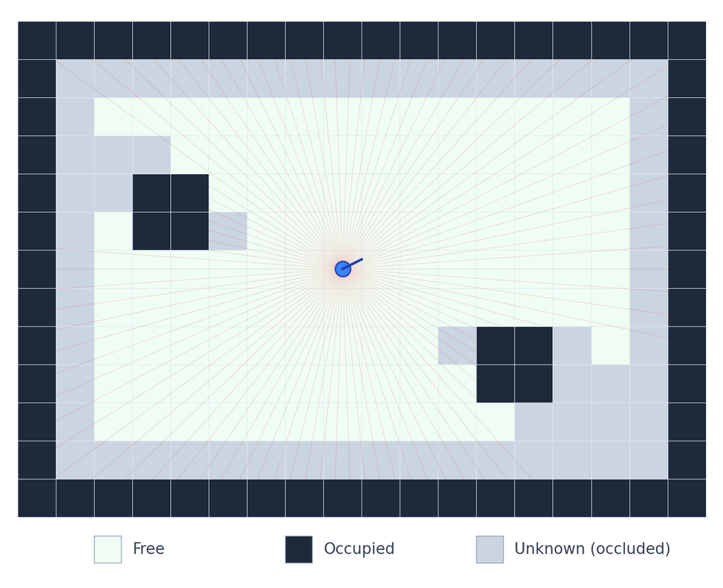

After processing all rays: cells are **white** (free), **black** (occupied), or **gray** (unknown/occluded).

## Practice: Building a Grid from a Scan

**Given:** A robot at grid position $(5, 5)$ on a $10 \times 10$ grid. Six LiDAR rays hit walls at:

| Ray | $\alpha$ (degrees) | Grid endpoint $(i, j)$ |
| --- | --- | --- |
| 1 | 0° (right) | $(9, 5)$ |
| 2 | 45° | $(8, 8)$ |
| 3 | 90° (up) | $(5, 9)$ |
| 4 | 135° | $(2, 8)$ |
| 5 | 180° (left) | $(1, 5)$ |
| 6 | 270° (down) | $(5, 1)$ |

**Task:** On paper, mark cells as Free (F), Occupied (O), or Unknown (U).

*(Work on this for 3 minutes, then we’ll see the solution.)*

## Practice: Solution

[figure not shown]

**For every ray:**

- **Free** — each cell the beam crosses
- **Occupied** — only the endpoint cell
- **Unknown** — everything not touched by a ray

Huge unknown wedges between rays — 6 beams can’t cover a full scene.

## The Problem: Sensor Noise

Real sensors are **noisy**:

- Scan 1 says cell $(5, 2)$ is **free**
- Scan 2 says cell $(5, 2)$ is **occupied**

A binary grid can only store one value.

**Which scan do we trust?**

Neither – we need to **accumulate evidence** over multiple observations.

[figure not shown]

## From Binary to Probabilistic

Instead of $\{0, 1, -1\}$, store a **probability** $p(\text{occupied})$ for each cell.

| $p$ | Meaning |
| --- | --- |
| 0.0 | Definitely free |
| 0.5 | Unknown |
| 1.0 | Definitely occupied |

**Update rule** (Bayes):

$$p(\text{occ} \mid z_{1:t}) = \frac{p(z_t \mid \text{occ})\, p(\text{occ} \mid z_{1:t-1})}{p(z_t)}$$

where

- $z_t$ — **current** measurement (*free* / *occupied*)
- $z_{1:t}$ — **all** measurements so far (scans $1$ → $t$)
- $p(\text{occ} \mid z_{1:t-1})$ — **prior** belief
- $p(z_t \mid \text{occ})$ — **sensor model** (likelihood of the reading if the cell is occupied)
- $p(z_t)$ — normaliser

But repeatedly multiplying small probabilities causes **numerical underflow**…

## The Log-Odds Representation

Define the **log-odds** of a probability:

$$l = \log\frac{p}{1 - p}$$

| $l$ | $p$ | Meaning |
| --- | --- | --- |
| $-\infty$ | 0.0 | Certain free |
| $-2.2$ | 0.1 | Likely free |
| $0$ | 0.5 | Unknown |
| $+2.2$ | 0.9 | Likely occupied |
| $+\infty$ | 1.0 | Certain occupied |

Inverse: $p = 1 / (1 + e^{-l})$ (sigmoid)

[interactive chart not shown]

**Key property:** Bayesian update becomes **addition** — no multiplications, no underflow.